# Part II - Prosper Loan Data Exploration

## by Vince Conca

## Investigation Overview

> Object of investigation: Prosper.com; Prosper is an online peer-to-peer (P2P) lending marketplace, where creditworthy borrowers can request a loan and investors can invest in “notes” (or portions) of each loan*.

> * from prosper.com

> Primarily, I wanted to explore what impact the main metrics/individual variables have on Prosper's internal risk rating for potential Borrowers. The scores range from 1 to 11 with 1 being the most risky Borrower and 11 being the least risky. It bears noting that per the definitions of the variables, the rating should only range from 1 to 10, not 1 to 11. Secondarily, I wanted to see how a Borrower's risk rating impacts approved loans through the lens of potential Investors by looking at the relationship between Borrower risk, their loan details, and Investor potential return.

> With that in mind, the variables I selected as having an affect on Prosper's risk score were:
> - Debt to Income Ratio (DTI)
> - Open Lines of Credit (LOC)
> - Revolving Credit Balance
> - Monthly Income
> - Credit Score

> For risk score impact to loans and in turn forecasted Investor return, I used:
> - Prosper Risk Score
> - APR
> - Term
> - Loan Amount
> - Esitmated Return

## Dataset Overview

> The datset contains 113,937 loans with 81 variables on each loan. Definitions for the 81 variables can be found in a downloadable file: Variable Definitions 43 variables contain null values and none contain duplicates. Variable data types are of integer, float, and string.

## Prosper's Risk Score

> With Prosper's risk score being the keystone variable for this entire presentation, we'll start with a view of the distribution. As seen, it's a mostly normalized plot, with a slight skew towards higher risk Borrowers (lower numbers = riskier Borrowers), which is an expected result. P2P lending models are typically geard more towards riskier Borrowers.

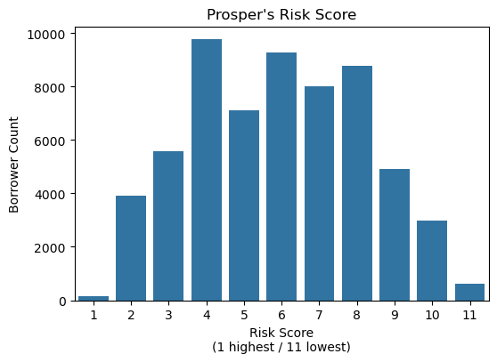

## Correlations between Prosper Risk Score, Debt to Income Ratio, Open LOC, Revolving Credit Balance, Monthiy Income, and Credit Score

> The null hypothesis in this investigation is no one variable is overly dominant than any other in determining Prosper risk score. This wasn't entirely proven out in the investigation. Credit score and monthly income did have a larger correlation vs the other variables when plotted against risk score. Though, I do not feel the correlations for credit score and monthly income were significant enough to discount the other variables importance. For that reason, the null hypothesis cannot unequivocally be rejected. In summary, the key insight from the primary investigation is no one metric contributed to Prosper's risk score to such a degree that it overwhelmed any other variable's impact, however credit score and monthly income are indeed more significant.

> To illustrate this, an overall correlation heatmap and then plottings of the individual variables from the heatmap against Prosper risk score will be shown.

> First, the heatmap. The first column shows the correlations for the risk score against the other variables.

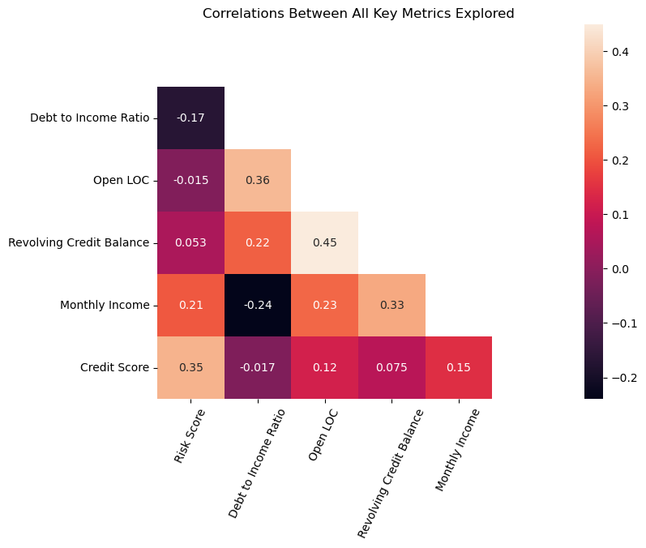

## Prosper Risk Score against Debt to Income Ratio (DTI)

> While the Interquartile Range (IQR) is similar with similar means across the dataset for each risk score, there is a gradual reduction in DTI as we move from more risk to less risk (left to right) as well as a gradual reduction in those above the max. The most risky (1), I find very interesting as the IQR spans the entirity of all the other scores. A possibile reason may be for the risk score of 1, that DTI isn't a large part of that particular calculation and other factors lead to a 1 risk score. On the flip side, the least risky (11), bucks the trend of decreasing DTI and mean DTI. They also have very few above the max when compared to all others.

> In general, if a Borrower wants the best risk score, in regards to DTI, they can have a high DTI, however the odds for a better risk score slightly increase with lower DTI with the absolute best (11), not being possible if DTI is over ~.55.

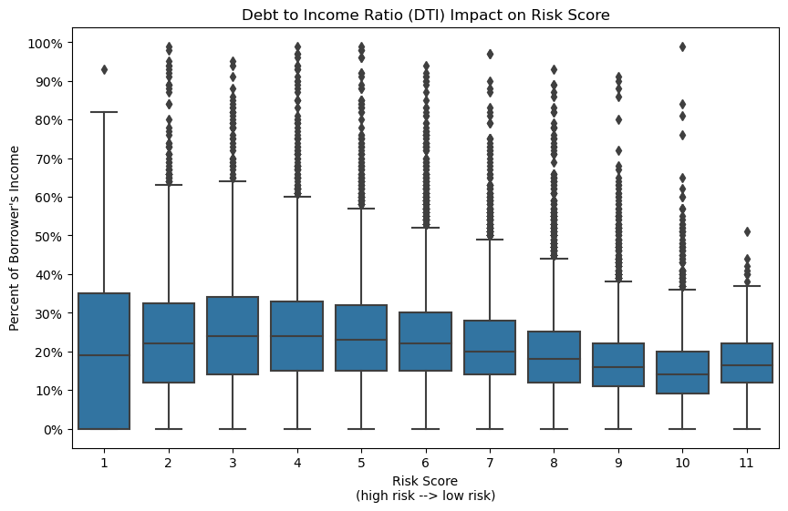

## Proser Risk Score against Open lines of credit

> The heatmap showed open lines of credit has the lowest correlation overall. Looking at the least risky Borrowers (9 - 11), it does have some impact, though. In short, the more open LOCs, the better.

> In general, to get the best risk scores, a Borrower must have at least 1 or 2 open lines of credit and if a Borrower wants the absolute best score, having a minimum of 4 credit lines looks to be a requirement and it's all good if the Borrower has a higher than average amount.

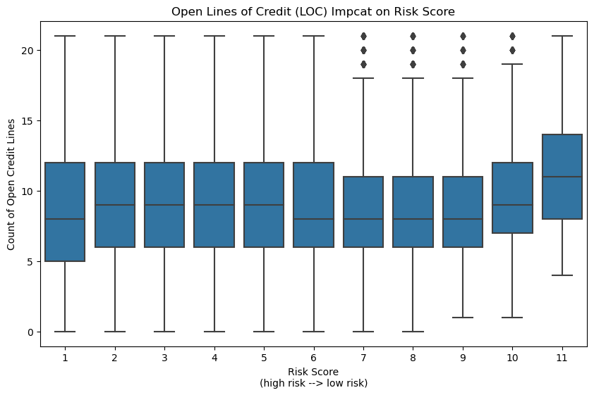

## Proser Risk Score against Revolving credit balance

> Revolving credit balance doesn't have a large impact on risk score as a stand alone metric, either. But a little like Open LOCs, it does a tad more towards the extremes. Overall, there is a slight increase in the total range of credit balance, IQR, and max value as risk moves from highest risk to least risk (left to right). The absolute best score (11), is more extreme in that those Borrowers look to have quite a bit more revolving crdit balance than anyone else.

> In general, if a Borrower wants the best risk scores, having a higher revolving credit balance will help their case.

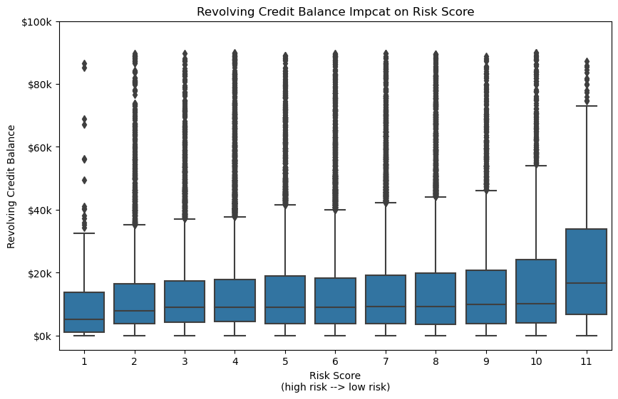

## Proser Risk Score against Monthly Income

> Per the heatmap, monthly income is the second highest correlated variable to risk score. A Borrower's risk score improves as their monthly income increases. This is very intuitive and expected. It also shows there is a much steeper minimum for the absolute best score, ~$3k a month. One thing of note, the most risky score (1) actually has a slighly higher minimum monthly income and monthly average income compared to the lower half of the scores. It's not much, but something of note. Borrowers with a 1 score also don't have very many high income earners, however, this aspect is not surprising.

> In general, it's pretty clear that if a Borrower wants the best risk scores, make more money.

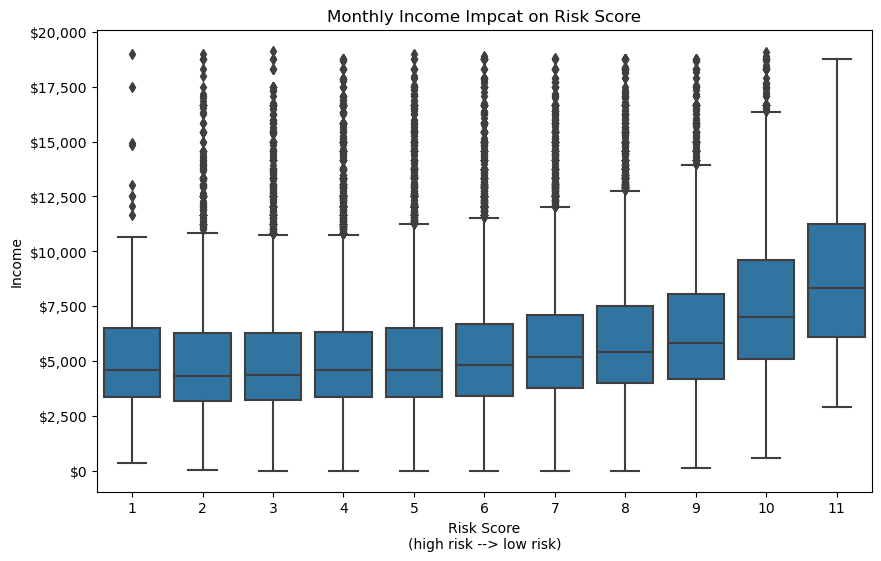

## Proser Risk Score against Credit Score

> Per the heatmap, the highest correlation to risk score is credit score. We see two plots below representing a split of the range of credit scores; lower credit scores (top plot) and higher credit scores (bottom plot). It's worth noting that all risk scores have Borrowers acorss all credit ratings. However, there are far more Borrowers with lower credit scores than higher. Also, in regards to the lower credit score view, as Borrower's risk scores improve, the count of borrowers gets smaller. This makes sense, as Borrower's credit rating go higher, they'd most likely have a better risk score as well and fall into the lower plot counts. And this is shown with the higher credit scores plot. As risk scores improve, borrowers with higher credit scores increase. However, this pattern stops with a risk score of 9 and above. For scores 9 - 11, the distribution is more normalized. A borrower has just about an equal shot of getting a favorable risk score with lower credit as they do with higher credit. This leads me to believe two things, one: at the best risk scores (9 - 11), credit rating isn't weighted as heavily and two: there simply are just fewer Borrowers overall with these high scores, so there's fewer data points for trends to present.

> It's also worth noting that the lowest credit score for Prosper is 649, which is considered 'good' credit by credit reporting bureaus, so we're really looking at a distribution of high credit scores in general.

> In general, if a Borrower wants the best risk scores, it helps to have a better credit score, however it's not entirely necessary.

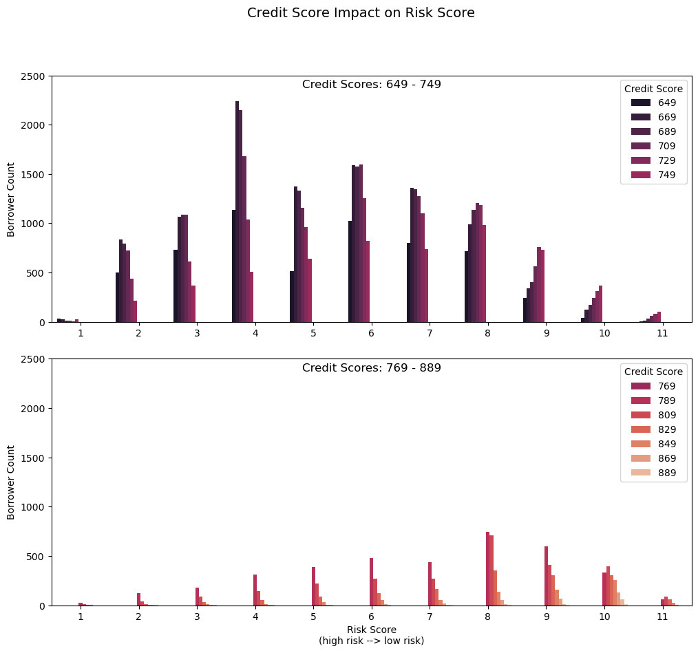

## Correlations between Prosper Risk Score and Borrower APR, Estimated Return, and Loan Amount

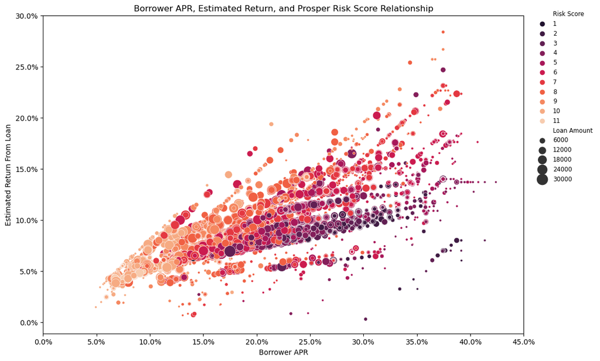